# Lab 2

Advanced Data Visualization

Author

Nicholas Soares

```r
library(tidyverse)
library(readxl)
library(ggridges)
library(RColorBrewer)
library(leaflet)
library(sf)
library(viridisLite)
library(gganimate)
```

# Instructions

**Create a Quarto file for ALL Lab 2 (no separate files for Parts 1 and 2).**

- Make sure your final file is carefully formatted, so that each analysis is clear and concise.
- Be sure your knitted `.html` file shows **all** your source code, including any function definitions.

# Part One: Identifying Bad Visualizations

If you happen to be bored and looking for a sensible chuckle, you should check out these [Bad Visualisations](https://badvisualisations.tumblr.com/). Looking through these is also a good exercise in cataloging what makes a visualization good or bad.

## Dissecting a Bad Visualization

Below is an example of a less-than-ideal visualization from the collection linked above. It comes to us from data provided for the [Wellcome Global Monitor 2018 report](https://wellcome.ac.uk/reports/wellcome-global-monitor/2018) by the Gallup World Poll:

[figure not shown]

1. While there are certainly issues with this image, do your best to tell the story of this graph in words. That is, what is this graph telling you? What do you think the authors meant to convey with it?

The median percentage of people who believe vaccines are safe vary between regions and there is high variability within regions as well. I think the authors wanted to highlight the differences in vaccine acceptance between regions and make inferences into why they differ.

2. List the variables that appear to be displayed in this visualization. *Hint: Variables refer to columns in the data.*

The variables are likely: Country, Region, “% of People Who Believe Vaccines are Safe” (which could be broken into multiple columns like “Population” and/or survey results), and Rank (by region)

3. Now that you’re versed in the grammar of graphics (e.g., `ggplot`), list the *aesthetics* used and which *variables* are mapped to each.

The aesthetics would be *x = “% of People Who Believe Vaccines are Safe”*, *y = rank* and *color = Region*

4. What type of graph would you call this? Meaning, what `geom` would you use to produce this plot?

I would use *geom_point()* and facet by Region

5. Provide at least four problems or changes that would improve this graph. *Please format your changes as bullet points!*
- Cleanup the text labels displayed within the plot (seems too busy)
- Label the y axis with “Rank by Region” so it is easier to interpret how the points are ordered
- Have the size of each regional subplot be consistent (same height), the current setup is visually unappealing
- Change the color of the vertical line representing the region median so it stands out

## Improving the Bad Visualization

The data for the Wellcome Global Monitor 2018 report can be downloaded at the following site: [https://wellcome.ac.uk/reports/wellcome-global-monitor/2018](https://wellcome.org/sites/default/files/wgm2018-dataset-crosstabs-all-countries.xlsx)

There are two worksheets in the downloaded dataset file. You may need to read them in separately, but you may also just use one if it suffices.

```r
#Loading spreadsheets
wgm<-read_xlsx("wgm2018-dataset-crosstabs-all-countries.xlsx",
               sheet="Full dataset")
notes<-read_xlsx("wgm2018-dataset-crosstabs-all-countries.xlsx",
                 sheet="Data dictionary")

#Q1 contains responses to the "Perceived scientific knowledge" question
#Q25 contains responses to the "Are vaccines safe" question

#creating a new, filtered data frame
wgm_filt<-wgm|>
  select(c(WP5,wgt,PROJWT,FIELD_DATE,YEAR_CALENDAR,
           Q1,Q25,AgeCategories,Regions_Report))|>
  filter(!is.na(Q25))

#Handling the country codes
countries<-t(str_split(notes[1,3],',',simplify = T))
countryCode<-str_split(countries,"=",simplify=T)
countryCode<-as.data.frame(countryCode)
colnames(countryCode)<-c("WP5","Country")
countryCode$WP5<-as.numeric(countryCode$WP5)

#Handling the region codes
regions<-t(str_split(notes[57,3],',',simplify=T))
regionCode<-str_split(regions,"=",simplify=T)
regionCode<-as.data.frame(regionCode)
colnames(regionCode)<-c("Regions_Report","Region")
regionCode$Regions_Report<-as.numeric(regionCode$Regions_Report)

#Merging country and region names
wgm_merge<-left_join(wgm_filt,countryCode)
wgm_merge<-left_join(wgm_merge,regionCode)

#New column for pro/anti vaccine
wgm_merge<-wgm_merge|>
  mutate(VacView=case_when(
    Q25 <= 2 ~ "Pro",
    Q25 >= 3 ~ "NotPro"
  ))

#Changing region groupings to match plot
plotRegions<-data.frame(Region=unique(wgm_merge$Region),
                        Plot=c("Americas","Middle East and North Africa",
                               "Middle East and North Africa","Asia","Asia",
                               "Europe","Europe","Europe","Former Soviet Union",
                               "Asia","Americas","Americas","Sub-Saharan Africa",
                               "Sub-Saharan Africa","Sub-Saharan Africa","Asia",
                               "Former Soviet Union","Sub-Saharan Africa","Not assigned"))
wgm_merge<-left_join(wgm_merge,plotRegions)

#Grouping by country for plotting
wgm_country<-wgm_merge|>
  group_by(Country,Plot,VacView)|>
  summarize(Count=n())#grouping by vaccine outlook
wgm_country2<-wgm_merge|>
  group_by(Country,Plot)|>
  summarize(Total=n())#total records from each country

#final merge and calculation of proportions
wgm_country<-left_join(wgm_country,wgm_country2)
wgm_props<-wgm_country|>
  mutate(Prop=Count/Total)|>
  filter(VacView=="Pro",Plot!="Not assigned")
wgm_props$Plot<-factor(wgm_props$Plot,
                       levels = c("Asia","Middle East and North Africa",
                                  "Sub-Saharan Africa","Americas","Europe",
                                  "Former Soviet Union"))
```

6. Improve the visualization above by either re-creating it with the issues you identified fixed OR by creating a new visualization that you believe tells the same story better.

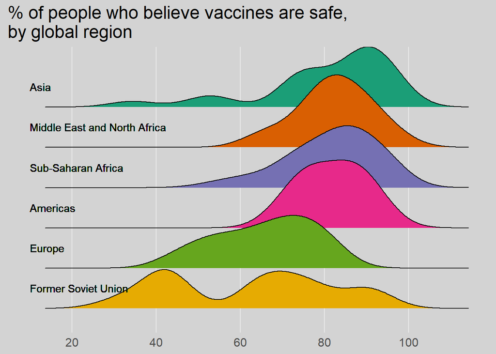

```r
ggplot(wgm_props,aes(Prop*100,Plot,fill = Plot))+
  geom_density_ridges()+ #easier to visualize than points and less busy
  geom_text(data=wgm_props,aes(label = Plot,x=10,hjust=0,vjust=-2))+
  scale_fill_brewer(palette = "Dark2")+ #color-blind friendly
  scale_y_discrete(limits=rev)+
  scale_x_continuous(breaks = seq(20,100,20))+
  labs(x=NULL,y=NULL,title=str_wrap("% of people who believe vaccines are safe, by global region",
                                    width = 42))+
  theme_minimal()+
  theme(legend.position="none",
        axis.text.y = element_blank(),
        text = element_text(size=15),
        panel.background = element_rect(fill = "lightgrey",color = "lightgrey"),
        plot.background = element_rect(fill="lightgrey",color="lightgrey"),
        panel.grid.minor.x = element_blank(),
        panel.grid.major.y = element_blank())
```

# Part Two: Broad Visualization Improvement

The full Wellcome Global Monitor 2018 report can be found here: https://wellcome.ac.uk/sites/default/files/wellcome-global-monitor-2018.pdf. Surprisingly, the visualization above does not appear in the report despite the citation in the bottom corner of the image!

## Second Data Visualization Improvement

**For this second plot, you must select a plot that uses maps so you can demonstrate your proficiency with the `leaflet` package!**

7. Select a data visualization in the report that you think could be improved. Be sure to cite both the page number and figure title. Do your best to tell the story of this graph in words. That is, what is this graph telling you? What do you think the authors meant to convey with it?

I selected Chart 2.3: “Map of perceived knowledge about science by country” on page 27. This map displays the percentage of people in each country surveyed that answered “a lot” or “some” in response to being questioned on how much they know about science. The authors are attempting to convey how perceived scientific knowledge is distributed around the world.

8. List the variables that appear to be displayed in this visualization.

Country and knowledge level are the primary variables.

9. Now that you’re versed in the grammar of graphics (ggplot), list the aesthetics used and which variables are specified for each.

If we were displaying data as a bar graph instead of a map, the aesthetics would be *x = “Country”*, *y = Knowledge Level* and/or *color = Knowledge Level*

10. What type of graph would you call this?

These data could be displayed with *geom_bar()*, but for the sake of this problem it was made into a chloropleth map using the leaflet package.

11. List all of the problems or things you would improve about this graph.
- The use of a monochromatic color bar makes it challenging to view the difference
- Lack of interactivity makes it impossible to view the exact values by country
12. Improve the visualization above by either re-creating it with the issues you identified fixed OR by creating a new visualization that you believe tells the same story better.

```r
#Data preparation
wgm_sci<-wgm_merge|>
  mutate(SciKnow=case_when(
    Q1 <= 2 ~ "Lots",
    Q1 >= 3 ~ "NotLots"
  ))

#Grouping by country for plotting
wgm_sci_country<-wgm_sci|>
  group_by(Country,SciKnow)|>
  summarize(Count=n())#grouping by scientific knowledge
wgm_sci_country<-left_join(wgm_sci_country,wgm_country2)

#Calculation of proportions
wgm_sci_props<-wgm_sci_country|>
  mutate(Prop=Count/Total*100)|>
  filter(SciKnow=="Lots")|>
  select(Country,Prop)
colnames(wgm_sci_props)<-c("NAME","KnowLevel")

#Loading in shapefile of countries for chloropleth map
#following guidelines outlined in https://r-graph-gallery.com/183-choropleth-map-with-leaflet.html
world_sf<-read_sf("~/Cal Poly/Spring 2025/STAT 541 - Advanced Stats with R/Lab 2/lab-2/TM_WORLD_BORDERS_SIMPL-0.3.shp")

wgm_sf<-world_sf|>
  filter(NAME %in% unique(wgm_sci_props$NAME))
wgm_sf<-left_join(wgm_sf,wgm_sci_props)

#Creating a color palette to display data
mypalette<-colorNumeric(
  palette="viridis",domain=wgm_sf$KnowLevel,
  na.color="transparent"
)

#Text labels
mytext<-paste(
  "Country: ",wgm_sf$NAME,"<br/>",
  "Knowledge Level: ",round(wgm_sf$KnowLevel,0),"%","</br>",
  sep=""
)%>%
  lapply(htmltools::HTML)

#Display map
leaflet(wgm_sf)%>%
  addTiles()%>%
  setView(lat=0,lng=0,zoom=0.5)%>%
  addPolygons(fillColor = ~mypalette(KnowLevel),stroke = F,
              label=mytext,fillOpacity = 0.9)%>%
  addLegend(pal = mypalette,values=~KnowLevel,
            title="Knowledge Level",position = "bottomleft",
            opacity=0.9)
```

[interactive chart not shown]

## Third Data Visualization Improvement

**For this third plot, you must use one of the other `ggplot2` extension packages mentioned this week (e.g., `gganimate`, `plotly`, `patchwork`, `cowplot`).**

13. Select a data visualization in the report that you think could be improved. Be sure to cite both the page number and figure title. Do your best to tell the story of this graph in words. That is, what is this graph telling you? What do you think the authors meant to convey with it?

I chose chart 2.5 on page 29, depicting “Perceived knowledge about science by region and age group”. This is expanding upon the data depicted in the map above by adding “Age Group” as a variable. The authors are showing that while there is an effect of country on knowledge level, there is also an effect of Age Group. The 15-29 age group in each region has the highest perception of scientific knowledge.

14. List the variables that appear to be displayed in this visualization.

The variables are region, age range, and knowledge level.

15. Now that you’re versed in the grammar of graphics (ggplot), list the aesthetics used and which variables are specified for each.

The aesthetics would be *x = Knowledge Level*, *y = Region* and *color = Age Range*.

16. What type of graph would you call this?

This would be a bar graph, *geom_bar()*

17. List all of the problems or things you would improve about this graph.
- The spacing of the bars make it difficult to see where regions/start and end, the bars should be more clearly grouped in clusters
- The text labels make the graph look busy and are redundant, since the bars already depict the data
- Harsh white background
18. Improve the visualization above by either re-creating it with the issues you identified fixed OR by creating a new visualization that you believe tells the same story better.

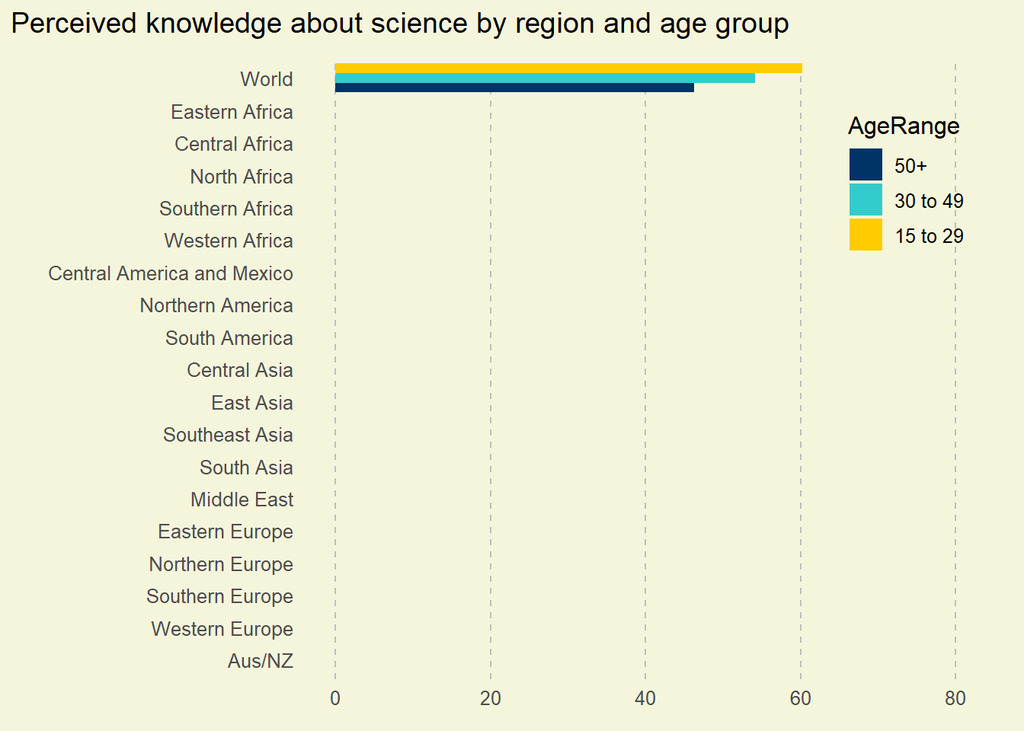

```r
#Grouping by region and age category
wgm_sci_region<-wgm_sci|>
  filter(!is.na(AgeCategories))|>
  group_by(Region,AgeCategories,SciKnow)|>
  summarize(Count=n())#grouping by scientific knowledge
wgm_sci_region2<-wgm_sci|>
  filter(!is.na(AgeCategories))|>
  group_by(Region,AgeCategories)|>
  summarize(Total=n())
wgm_sci_region<-left_join(wgm_sci_region,wgm_sci_region2)

#Calculation of proportions by age range and region
wgm_sci_age<-wgm_sci_region|>
  mutate(Prop=Count/Total)|>
  filter(SciKnow=="Lots"&Region!="Not assigned")|>
  select(Region,AgeCategories,Prop)

#Calculating World totals
world_age_totals<-wgm_sci_age|>
  group_by(AgeCategories)|>
  summarize(Prop=mean(Prop))|>
  mutate(Region="World")|>
  relocate(Region,.before=AgeCategories)
wgm_sci_age<-rbind(wgm_sci_age,world_age_totals)

#Factoring Region and Age Range for plotting order
wgm_sci_age$Region<-factor(wgm_sci_age$Region,
                           levels = c("World","Eastern Africa","Central Africa",
                                      "North Africa","Southern Africa","Western Africa",
                                      "Central America and Mexico","Northern America",
                                      "South America","Central Asia","East Asia",
                                      "Southeast Asia","South Asia","Middle East",
                                      "Eastern Europe","Northern Europe","Southern Europe",
                                      "Western Europe","Aus/NZ"))
wgm_sci_age<-wgm_sci_age|>
  mutate(AgeRange=case_when(
    AgeCategories == 1 ~ "15 to 29",
    AgeCategories == 2 ~ "30 to 49",
    AgeCategories == 3 ~ "50+"
  ))
wgm_sci_age$AgeRange<-factor(wgm_sci_age$AgeRange,
                             levels = c("50+","30 to 49","15 to 29"))

#Plotting with gganimate
ggplot(wgm_sci_age,aes(Prop*100,Region,fill=AgeRange),color="black")+
  geom_bar(stat="identity",position = "dodge")+
  scale_y_discrete(limits=rev)+
  scale_fill_manual(values=c("#003366","#33CCCC","#FFCC00"))+ #liked the color scheme of the original plot
  labs(x=NULL,y=NULL,title="Perceived knowledge about science by region and age group")+
  theme_minimal()+
  theme(legend.position = c(0.85,0.8),
        panel.grid.minor.x = element_blank(),
        panel.grid.major.y = element_blank(),
        text = element_text(size=12),
        panel.background = element_rect(fill = "beige",color = "beige"),
        plot.background = element_rect(fill="beige",color="beige"),
        panel.grid.major.x = element_line(linetype = "dashed",colour = "grey"),
        plot.title.position = "plot")+
  transition_states(Region,wrap=F)+
  shadow_mark()+
  enter_fade()
```